# Stat 480 - Homework #7

3/1/2018

## Star Wars

1. Download the RMarkdown file with these homework instructions to use as a template for your work. Make sure to replace “Your Name” in the YAML with your name.
2. We are back to a survey collected by FiveThirtyEight. This time we are interested in a survey on Star Wars - the accompanying article is published [here](https://fivethirtyeight.com/features/americas-favorite-star-wars-movies-and-least-favorite-characters/)

```r
library(tidyverse)
starwars <- read_csv("https://raw.githubusercontent.com/fivethirtyeight/data/master/star-wars-survey/StarWars.csv")

# the following lines are necessary to make the second line of the file
# part of the names:
line1 <- names(starwars)
line2 <- unlist(starwars[1,])
varnames <- paste(line1, line2)
# clean up some of the multibyte characters:
names(starwars) <- enc2native(stringi::stri_trans_general(varnames, "latin-ascii"))

starwars <- starwars[-1,]
```

3. How many people respondent to the survey? How many people have seen at least one of the movies? Use the variable `Have you seen any of the 6 films in the Star Wars franchise? Response` to answer this question. Only consider responses of participants who have seen at least one of the Star Wars films for the remainder of the homework.

```r
library(dplyr)
starwars2 <- starwars %>% filter(`Have you seen any of the 6 films in the Star Wars franchise? Response`=="Yes")
dim(starwars2)
```

```
## [1] 936  38
```

936 people who responded to the survey have seen at lesat one of the movies.

4. Variables `Gender Response` and `Age Response` are two of the demographic variables collected. Use `dplyr` to provide a frequency break down for each variable. Does the result surprise you? Comment. Reorder the levels in the variable `Age Response` from youngest to oldest.

```r
levels(factor(starwars2$`Age Response`))
```

```
## [1] "> 60"  "18-29" "30-44" "45-60"
```

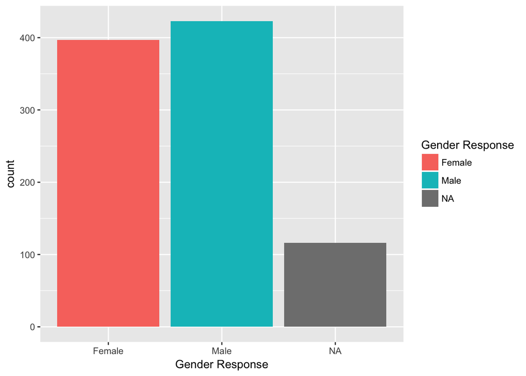

```r
starwars2$`Age Response` <-factor(starwars2$`Age Response`, levels=c("18-29", "30-44", "45-60", "> 60"))

starwars2 %>% ggplot(aes(x=`Gender Response`, fill=`Gender Response`)) + geom_bar()
```

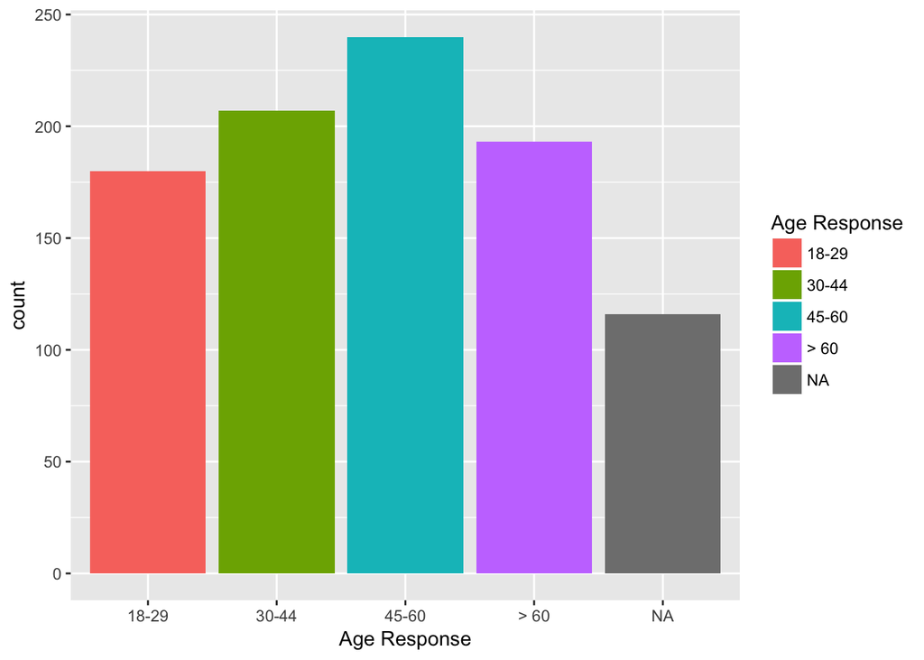

```r
starwars2 %>% ggplot(aes(x=`Age Response`, fill=`Age Response`))+ geom_bar()
```

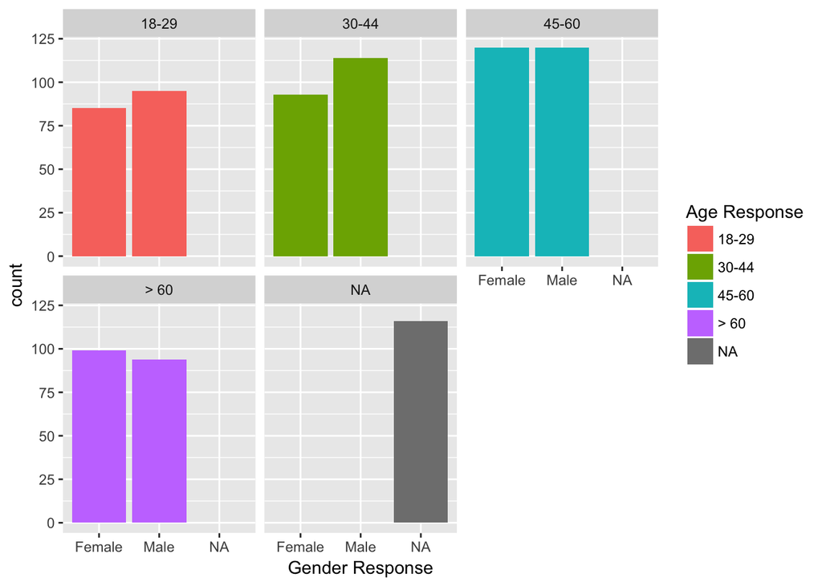

```r
starwars2 %>% ggplot(aes(x=`Gender Response`, fill=`Age Response`)) + geom_bar() + facet_wrap(~`Age Response`)
```

I will admit to being a little surprised, as I hadn’t expected the viewership breakdown by gender to be quite that close. The age breakdown showing the largest share of viewers as being between age 45-60 is less surprising, given how long the series has been around. By breaking it down by age, the trend is also interesting in that the count of viewers evens out in the 45-60 bracket, then seems to show a female majority viewership after 60 years of age.

5. Variables 10 through 15 answer the question: “Please rank the Star Wars films in order of preference with 1 being your favorite film in the franchise and 6 being your least favorite film.” for each of the films. Use `dplyr` to find the average rank for each of the films (Note: you will first have to cast the responses to numbers). Are average ranks different between the mens’ and womens’ rankings? On how many responses are the averages based? Show these numbers together with the averages.

```r
starwars2 %>% group_by(`Gender Response`) %>% summarise(m.TPM = mean(as.numeric(`Please rank the Star Wars films in order of preference with 1 being your favorite film in the franchise and 6 being your least favorite film. Star Wars: Episode I  The Phantom Menace`),na.rm=TRUE), m.AoTC=mean(as.numeric(`X11 Star Wars: Episode II  Attack of the Clones`), na.rm=TRUE), m.RotS=mean(as.numeric(`X12 Star Wars: Episode III  Revenge of the Sith`), na.rm=TRUE), m.ANH=mean(as.numeric(`X13 Star Wars: Episode IV  A New Hope`), na.rm=TRUE), m.TESB=mean(as.numeric(`X14 Star Wars: Episode V The Empire Strikes Back`),  na.rm=TRUE), m.RotJ=mean(as.numeric(`X15 Star Wars: Episode VI Return of the Jedi`), na.rm=TRUE), n=n())
```

```
## # A tibble: 3 x 8
##   `Gender Response` m.TPM m.AoTC m.RotS m.ANH m.TESB m.RotJ     n
##   <chr>             <dbl>  <dbl>  <dbl> <dbl>  <dbl>  <dbl> <int>
## 1 Female             3.43   3.95   4.42  3.54   2.57   3.08   397
## 2 Male               4.04   4.22   4.27  3.00   2.46   3.00   423
## 3 <NA>               3.19   3.75   4.19  3.81   2.56   3.50   116
```

The averages are taken from 397 female responses, and 423 male responses.

Men and women appear to have the largest difference in opinion in Episodes I: The Phantom Menace and IV: A New Hope with Women showing a higher preference than men for Episode 1, while men rank episode IV higher than women. Beyond those two, the ratings appear fairly similar between the genders, most notably in Episode VI, with the means averaging very close to 3. Overall, Episode V: The Empire Strikes Back appears to be the most popular, with a female rank of 2.57 and a male rank of 2.46. Episode III: Revenge of the Sith is the least popular, averaging a female ranking of 4.42 and a male ranking of 4.27.

While the missing responses may have a slight effect on overall rating, it is more likely that the rankings are primarily influenced by gender.

6. R2 D2 or C-3P0? Which of these two characters is the more popular one? Use responses to variables 25 and 26 to answer this question. Note: first you need to define “popularity” based on the available data.

```r
starwars2 %>% group_by(`X25 C-3P0`) %>% summarise(n=length(`RespondentID NA`))
```

```
## # A tibble: 7 x 2
##   `X25 C-3P0`                                     n
##   <chr>                                       <int>
## 1 Neither favorably nor unfavorably (neutral)    79
## 2 Somewhat favorably                            229
## 3 Somewhat unfavorably                           23
## 4 Unfamiliar (N/A)                               15
## 5 Very favorably                                474
## 6 Very unfavorably                                7
## 7 <NA>                                          109
```

```r
starwars2 %>% group_by(`X26 R2 D2`) %>% summarise(n = length(`RespondentID NA`))
```

```
## # A tibble: 7 x 2
##   `X26 R2 D2`                                     n
##   <chr>                                       <int>
## 1 Neither favorably nor unfavorably (neutral)    57
## 2 Somewhat favorably                            185
## 3 Somewhat unfavorably                           10
## 4 Unfamiliar (N/A)                               10
## 5 Very favorably                                562
## 6 Very unfavorably                                6
## 7 <NA>                                          106
```

```r
starwars2$`X25 C-3P0` <-factor(starwars2$`X25 C-3P0`, levels=c("Unfamiliar (N/A)", "Very unfavorably", "Somewhat unfavorably", "Neither favorably nor unfavorably (neutral)", "Somewhat favorably", "Very favorably"))

starwars2$`X26 R2 D2` <-factor(starwars2$`X26 R2 D2`, levels=c("Unfamiliar (N/A)", "Very unfavorably", "Somewhat unfavorably", "Neither favorably nor unfavorably (neutral)", "Somewhat favorably", "Very favorably"))

starwars2 %>% filter((`X25 C-3P0`!="Unfamiliar (N/A)") & (`X26 R2 D2` !=
                      "Unfamiliar(N/A")) %>% summarise(m.C =
                      mean(as.numeric(`X25 C-3P0`), na.rm=TRUE), m.R=mean(as.numeric
                      (`X26 R2 D2`), na.rm=TRUE))
```

```
## # A tibble: 1 x 2
##     m.C   m.R
##   <dbl> <dbl>
## 1  5.40  5.56
```

Given the above, it appears that R2 D2 is the more popular character, though both are apparently viewed as favorable.

Due date: the homework is due before class on Thursday.

For the submission: submit your solution in an R Markdown file and (just for insurance) submit the corresponding html file with it.